# Medidas de tendencia central

[Brenda Michelle Ramírez Jiménez](https://brendarj.github.io)

Estadística 2022-2, [Facultad de economía](http://www.economia.unam.mx/)

2/3/2022

### 1. ¿Qué son las medidas de tendencia central? 🤔

> “La medida de tendencia central (moda,media y mediana), parámetro de tendencia central o medida de centralización es un número ubicado hacia el centro de la distribución de los valores de una serie de observaciones (medidas), en la que se encuentra ubicado el conjunto de los datos. Las medidas de tendencia central más utilizadas son: media, mediana u moda.”

[Wikipedia (2020)](https://es.wikipedia.org/wiki/Medidas_de_tendencia_central)

Para este ejemplo, primero generaremos una serie de **100** números aleatorios entre **1** y **20** mediante la función `sample`. El argumento `TRUE` nos permitirá generar una muestra con remplazo:

```r
numeros <- sample(1:20, 100, TRUE)
numeros
```

```
##   [1] 11 11  8 13 19 16  8  7 17  3 19  8  4 20 13  9  5  8 12  2 12 12  5 20 16
##  [26] 16  6  2 18  6  4  4  4  1  3 15 16  6  1 19  2  1  4  6 12 19 15 19 14  8
##  [51]  1  7 17  6  7  7  4 20 13 15 17 10 17 20  7 11 12 16  3 16 12  2 10  3  3
##  [76] 19 17  6 16 20 14 12 13  8  8 12  4 20  7  7  2 14  2 12 15 14 13  4 17 10
```

### 2. Mediana 📍

> “La mediana es un [estadístico](https://economipedia.com/definiciones/estadistico.html) de posición central que parte la distribución en dos, es decir, deja la misma cantidad de valores a un lado que a otro”

[Economipedia (2019)](https://economipedia.com/definiciones/mediana.html)

Para obtener la **mediana**, podemos ordenar los `numeros` de menor a mayor, **el número que esté en medio de la muestra será la mediana**. Si utilizamos R, se puede hacer el cálculo de la **mediana** con la función `median`:

```r
mediana <- median(numeros)
mediana
```

```
## [1] 11
```

### 3. Media 🧮

> “La media es el valor promedio de un conjunto de datos numéricos, calculada como la suma del conjunto de valores dividida entre el número total de valores. La media, a diferencia de la esperanza matemática, es un término matemático”

[Economipedia (2018)](https://economipedia.com/definiciones/media.html#:~:text=La%20media%20es%20el%20valor,matem%C3%A1tica%2C%20es%20un%20t%C3%A9rmino%20matem%C3%A1tico.)

$$Media ={\frac {1}{n}}\sum _{i=1}^{n}a_{i}={\frac {a_{1}+a_{2}+\cdots +a_{n}}{n}}$$

Si usamos R, podemos obtener la media de una muestra si utlilizamos la función **mean**:

```r
media <- mean(numeros)
media
```

```
## [1] 10.41
```

### 4. Moda 📊

> “La moda es el valor que más se repite en una muestra estadística o población. No tiene fórmula en sí mismo. Lo que habría que realizar es la suma de las repeticiones de cada valor.”

[Economipedia (2019)](https://economipedia.com/definiciones/medidas-de-tendencia-central.html)

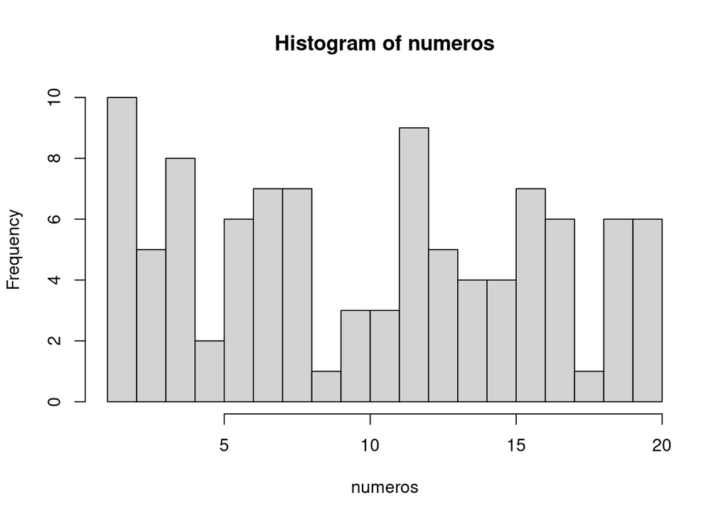

```r
# El argumento breaks nos permite dividir en histograma en las partes que queramos
hist(numeros, breaks = 20)
```

Para obtener un resultado con más precisión, podemos obtener la **moda** si generamos una **tabla de frecuencias** con la función `table` y la función `data.frame`, **aquel elemento con mayor frecuencia será la moda**:

```r
tabla.frecuencias <- data.frame(table(numeros))
tabla.frecuencias
```

```
##    numeros Freq
## 1        1    4
## 2        2    6
## 3        3    5
## 4        4    8
## 5        5    2
## 6        6    6
## 7        7    7
## 8        8    7
## 9        9    1
## 10      10    3
## 11      11    3
## 12      12    9
## 13      13    5
## 14      14    4
## 15      15    4
## 16      16    7
## 17      17    6
## 18      18    1
## 19      19    6
## 20      20    6
```

### 5. Ejercicio 👩‍💻👨‍💻✍

Aplica lo que aprendiste, obten la **mediana**, **media** y **moda** de la siguiente muestra de números:

```r
# Con la función seq, creamos una secuencia de 1 a 10 en intervalos de 0.1 en 0.1
secuencia <- seq(1, 10, 0.1)
muestra <- sample(secuencia, 100, TRUE)
muestra
```

```
##   [1] 1.9 8.4 5.9 5.6 2.1 5.5 4.1 4.5 2.9 7.4 7.7 9.2 3.1 2.6 9.1 9.7 4.6 7.6
##  [19] 5.1 8.2 9.3 9.7 2.1 5.7 6.6 8.4 9.7 5.8 8.1 9.9 8.6 9.4 8.8 8.7 1.8 4.7
##  [37] 5.8 7.0 4.1 5.0 4.4 4.5 4.5 3.9 5.6 7.4 2.6 5.2 4.2 3.8 5.0 5.7 4.4 5.2
##  [55] 7.0 6.1 3.0 7.3 4.7 1.1 6.4 1.0 4.8 4.7 8.9 9.0 3.8 4.0 1.5 8.5 7.8 6.0
##  [73] 4.8 5.3 6.1 7.9 1.3 4.6 9.1 2.2 1.0 8.5 7.3 2.7 6.3 1.0 3.3 5.1 6.7 5.3
##  [91] 1.8 8.8 9.5 9.0 6.1 2.2 9.2 4.9 6.9 7.8
```

##### Mediana

```r
# Aquí el cálculo de la mediana
mediana.muestra <- median(muestra)
mediana
```

[output not shown]

```
## [1] 11
```

##### Media

```r
# Aquí el cálculo de la media
media.muestra <- mean(muestra)
media
```

[output not shown]

```
## [1] 10.41
```

##### Moda

```r
# Aquí el cálculo de la moda
tabla.muestra <- data.frame(table(muestra))
tabla.muestra
```

```
##    muestra Freq
## 1        1    3
## 2      1.1    1
## 3      1.3    1
## 4      1.5    1
## 5      1.8    2
## 6      1.9    1
## 7      2.1    2
## 8      2.2    2
## 9      2.6    2
## 10     2.7    1
## 11     2.9    1
## 12       3    1
## 13     3.1    1
## 14     3.3    1
```

[output cut: 50 more lines]

💻[Código disponible en RStudio Cloud](https://rstudio.cloud/project/3671022)💻